# Chapter 7 Principal component analysis (PCA)

Large datasets with many variables have become across different disciplines. To effectively interpret these datasets, it’s important to use methods that can significantly reduce their dimensionality while retaining the majority of the information. Principal component analysis (PCA) stands out as one of the most methods for the purpose. PCA operates on a straightforward principle: reduce the dataset's dimensionality while maintaining maximal 'variability’ as much as possible.

The primary objective of PCA is to produce an optimal data summary using a much smaller number of Principal components (PCs). The first principal component represents the direction of maximum variability (covariance) within the data. The second principal component is the subsequent orthogonal (uncorrelated) direction of greatest variability. Therefore, the process involves eliminating all variability along the first component and subsequently identifying the next direction of greatest variability. This iterative procedure continues until all relevant principal components have been identified.

The math formula for PCA:

$$\textbf{X} = \left(\begin{array}{c} X_1\\ X_2\\ \vdots \\X_p\end{array}\right)$$\begin{array}{lll} Y_1 & = & \phi_{11}X_1 + \phi_{12}X_2 + \dots + \phi_{1p}X_p \\ Y_2 & = & \phi_{21}X_1 + \phi_{22}X_2 + \dots + \phi_{2p}X_p \\ & & \vdots \\ Y_p & = & \phi_{p1}X_1 + \phi_{p2}X_2 + \dots +\phi_{pp}X_p\end{array}$$\text{var}(Y_i) = \sum\limits_{k=1}^{p}\sum\limits_{l=1}^{p}\phi_{ik}\phi_{il}\sigma_{kl} = \mathbf{\phi}'_i\Sigma\mathbf{\phi}_i$$

PCs are linear combinations of the original variables

\begin{array}{c} \mathbf{z_1} = v_{11} \mathbf{x_1} + \dots + v_{p1} \mathbf{x_p} \\ \mathbf{z_2} = v_{12} \mathbf{x_1} + \dots + v_{p2} \mathbf{x_p} \\ \vdots \\ \mathbf{z_k} = v_{1k} \mathbf{x_1} + \dots + v_{pk} \mathbf{x_p} \\ \end{array}

In matrix form: $$ \mathbf{Z} = \mathbf{X V} $$

PC1 The first principal component is the linear combination of x-variables that has maximum variance (among all linear combinations). The first pricinpal component is the corresponding eigen vector of the largest eigenvalue for the covariance matrix. It accounts for as much variation in the data as possible if only one component is used.

$$ Z_1 = \phi_{11}X_1 + \phi_{21} X_2 + \cdots + \phi_{p1} X_p $$$$ \max_{\phi{11},\phi_{21},\ldots,\phi_{p1}} \frac{1}{n} \sum_{i=1}^n \left( \sum_{j=1}^p \phi_{j1} x_{ij} \right)^2 \\ \mathrm{s.t.} \sum_{j=1}^p \phi_{j1}^2 = 1 $$

Applications of PCA:

Image Compression: it can be used to compress images by reducing their dimensionality while preserving most of the essential information. This is particularly useful in fields like image processing and computer vision.

Bioinformatics: In genomics and proteomics, where datasets often have a high dimensionality (e.g., gene expression data), it can help in identifying patterns and reducing noise, aiding in tasks like clustering, classification, and visualization of biological data.

Finance: it is widely used in financial modeling and portfolio management. It helps in analyzing the correlations between different financial assets and in constructing diversified portfolios that maximize returns while minimizing risk.

Signal Processing: It can be applied to analyze signals and extract relevant features, making it useful in fields such as telecommunications, speech recognition, and seismic analysis.

Chemometrics: In chemistry, PCA is used for analyzing spectroscopic data and identifying patterns in chemical compounds. It helps in reducing the complexity of data while retaining the most relevant information for further analysis.

Neuroscience: It is utilized in analyzing neuroimaging data (e.g., fMRI, EEG) to identify patterns of brain activity and to reduce the dimensionality of data for visualization and interpretation.

We would like to use a few Pcs to capture most of the variation of all variables. Totally , if there are p variable, we can have p principal components . We would like not to keep all p Pcs.

[figure not shown]

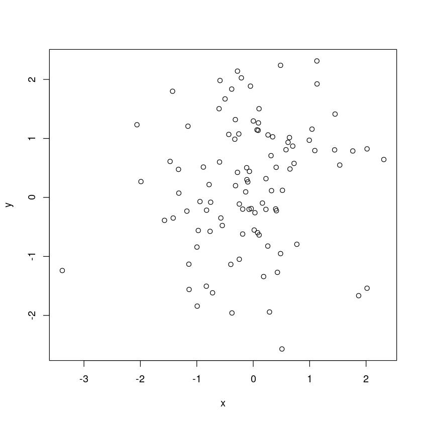

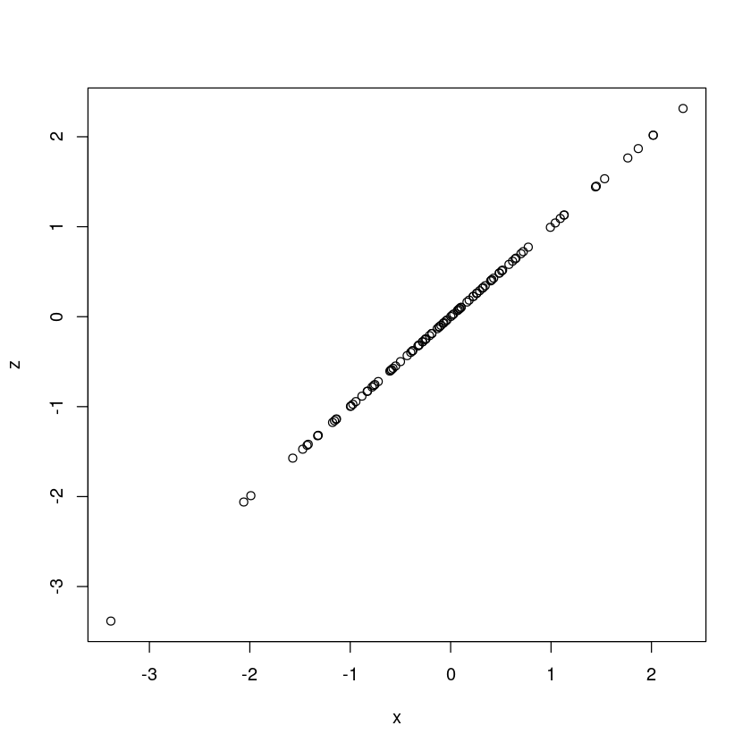

```r
x= rnorm(100, 0, 1)
y =rnorm(100, 0 , 1)

plot(x,y)

#In this case, PCA does not help, because x, and y are not related

z = x
plot(x,z)

#PC1 captures 100% of the variation,  because x and y are perfectly related
```

Run a PCA analysis to see if a few components can be used to capture the majority of information of all variables in Sparrow data.

```r
#Example:   the sparrow bird data. Run a principle component analysis.
#https://search.r-project.org/CRAN/refmans/Sleuth2/html/ex2016.html

#Load the file in datasciences.tamucc.edu
loc1 ="~//distribute_files//data//Bumpus_sparrows.csv"
sparrow1.dat = read.csv( loc1,  header = 1 )
head(sparrow1.dat)

#Five variables : for the size of a bird. Intutively, these variables are related.
#correlation plot
```

A data.frame: 6 × 6

|  | Survivorship <chr> | Total_length <int> | Alar_extent <int> | L_beak_head <dbl> | L_humerous <dbl> | L_keel_sternum <dbl> |
| --- | --- | --- | --- | --- | --- | --- |
| 1 | S | 156 | 245 | 31.6 | 18.5 | 20.5 |
| 2 | S | 154 | 240 | 30.4 | 17.9 | 19.6 |
| 3 | S | 153 | 240 | 31.0 | 18.4 | 20.6 |
| 4 | S | 153 | 236 | 30.9 | 17.7 | 20.2 |
| 5 | S | 155 | 243 | 31.5 | 18.6 | 20.3 |
| 6 | S | 163 | 247 | 32.0 | 19.0 | 20.9 |

```r
#Data with only quantitative variables
#Data matrix
dat = sparrow1.dat[, -1]
head(dat)
```

A data.frame: 6 × 5

|  | Total_length <int> | Alar_extent <int> | L_beak_head <dbl> | L_humerous <dbl> | L_keel_sternum <dbl> |
| --- | --- | --- | --- | --- | --- |
| 1 | 156 | 245 | 31.6 | 18.5 | 20.5 |
| 2 | 154 | 240 | 30.4 | 17.9 | 19.6 |
| 3 | 153 | 240 | 31.0 | 18.4 | 20.6 |
| 4 | 153 | 236 | 30.9 | 17.7 | 20.2 |
| 5 | 155 | 243 | 31.5 | 18.6 | 20.3 |
| 6 | 163 | 247 | 32.0 | 19.0 | 20.9 |

```r
#the raw data
fit = prcomp(dat)
summary(fit)

#PC1:  0.8622,  the first Principal component captures 86.2% of total variation of these 5 variables

#To get the first componenent
PC1 = fit$rotation[,1]

round(PC1, 2)


#The second PC
PC2 = fit$rotation[,2]

round(PC2, 2)
```

```
Importance of components:
                          PC1    PC2    PC3     PC4     PC5
Standard deviation     5.9435 2.1500 0.7943 0.55927 0.27843
Proportion of Variance 0.8622 0.1128 0.0154 0.00763 0.00189
Cumulative Proportion  0.8622 0.9751 0.9905 0.99811 1.00000
```

**Total_length**

0.54

**Alar_extent**

0.83

**L_beak_head**

0.1

**L_humerous**

0.07

**L_keel_sternum**

0.1

**Total_length**

-0.83

**Alar_extent**

0.55

**L_beak_head**

-0.03

**L_humerous**

0.01

**L_keel_sternum**

-0.1

The first PC (Principal component) is 0.54xTotal_length + 0.83 x Alar_extent + 0.1 x L_beak_head + 0.07 x L_humerous + 0.1 x L_keel_sternum

PC1: 0.8622, the first Principal component captures 86.2% of total variation of these 5 variables

PC2: 0.1128, the second Principal component captures 11.3% of total variation of these 5 variables

The first two PCs capture 0.9751 (0.8622 + 0.1128) of the total variation of all these 5 variables.

```r
#PCA on the scaled data
#Units may have big influece on PCA  ( kg,   g)
dat.s = scale(dat)
#round(mean(dat.s[,2]),5)
#var(dat.s[,2])
#The new transformed variables have  mean of zero and variance of 1
#head(dat.s)


fit.s = prcomp(dat.s)
summary(fit.s)

#To get the first componenent
PC1 = fit.s$rotation[,1]
round(PC1, 2)

#The second PC
PC2 = fit.s$rotation[,2]
round(PC2, 2)
```

```
Importance of components:
                          PC1    PC2     PC3     PC4     PC5
Standard deviation     1.9016 0.7290 0.62163 0.54915 0.40562
Proportion of Variance 0.7232 0.1063 0.07728 0.06031 0.03291
Cumulative Proportion  0.7232 0.8295 0.90678 0.96709 1.00000
```

**Total_length**

0.45

**Alar_extent**

0.46

**L_beak_head**

0.45

**L_humerous**

0.47

**L_keel_sternum**

0.4

**Total_length**

-0.05

**Alar_extent**

0.3

**L_beak_head**

0.32

**L_humerous**

0.18

**L_keel_sternum**

-0.88

```r
###Simple version, without data transformation,  PCA on the scaling data
fit.s = prcomp(dat, center = TRUE, scale = TRUE)

summary(fit.s)

#To get the first componenent
PC1 = fit.s$rotation[,1]
round(PC1, 2)

#The second PC
PC2 = fit.s$rotation[,2]
round(PC2, 2)

#Same results as the  PCA on the scaled data
```

```
Importance of components:
                          PC1    PC2     PC3     PC4     PC5
Standard deviation     1.9016 0.7290 0.62163 0.54915 0.40562
Proportion of Variance 0.7232 0.1063 0.07728 0.06031 0.03291
Cumulative Proportion  0.7232 0.8295 0.90678 0.96709 1.00000
```

**Total_length**

0.45

**Alar_extent**

0.46

**L_beak_head**

0.45

**L_humerous**

0.47

**L_keel_sternum**

0.4

**Total_length**

-0.05

**Alar_extent**

0.3

**L_beak_head**

0.32

**L_humerous**

0.18

**L_keel_sternum**

-0.88

```r
#If we would like to have at least 80% variation be captured,  at least 2 PCs should be used.
```

# The optimal number of components

Determining the Number of Principal Components

Determining the **optimal number of principal components** is not a straightforward task. It often involves a degree of subjectivity and depends on the goals of the analysis, the structure of the data, and the desired balance between simplicity and accuracy. Although several quantitative tools can assist in this decision-making process, they may not always yield a definitive answer.

Commonly used approaches for selecting the number of components include:

1. **Cumulative variance criterion:**  
   Retain enough components to collectively explain at least **80% (or more)** of the total variance in the data.
2. **Kaiser’s criterion:**  
   Keep components with **eigenvalues greater than 1**, as each such component explains more variance than a single standardized variable.
3. **Scree plot examination:**  
   Identify the **point of inflection** (the “elbow”) in the scree plot, where additional components contribute only marginally to the total variance explained.

The **eigenvalues** corresponding to each principal component provide direct insight into how much variance that component explains within the dataset.  
For example, suppose the total variance equals $5.000$. If the first principal component has an eigenvalue of $3.616$, it accounts for:

$$ \frac{3.616}{5.000} \times 100\% = 72.3\% $$

of the total variance. The next components might explain **10.6%**, **7.7%**, **6.0%**, and **3.3%**, respectively—indicating that the importance of each successive component diminishes rapidly after the first.

Another way to interpret the results is by comparing the **variance of each principal component** to the variance of the original standardized variables (each having a variance of $1.0$). In this context, the first principal component exhibits a variance equivalent to **3.616 original variables**, while the second accounts for only **0.532** of a single original variable, with subsequent components contributing even less. This comparison reinforces the **dominant role of the first principal component**, highlighting its ability to capture the majority of the underlying structure in the dataset, while later components primarily represent smaller, residual sources of variation.

```r
#Eigen value calculation  [not this one, to apply Kaiser’s criterion ]
cov.mat = cov(dat)
eigen(cov.mat)

#eigen value of the correlation matrix
cor.mat = cor(dat)
eigen(cor.mat)
#[1] 3.6159783 0.5315041 0.3864245 0.3015655 0.1645275
#according to Kaiser’s criterion: keep components with eigenvalues greater than 1, as each such component explains more variance than a single standardized variable.
# 1 PC should be used.
```

```
eigen() decomposition
$values
[1] 35.32575695  4.62245934  0.63091779  0.31278363  0.07752107

$vectors
            [,1]        [,2]        [,3]        [,4]        [,5]
[1,] -0.53650052  0.82809990  0.15649065 -0.04020969 -0.01765243
[2,] -0.82901535 -0.55051223  0.05774395 -0.06902156  0.03964203
[3,] -0.09649615  0.03356237 -0.23751487  0.89762653  0.35695288
[4,] -0.07435219 -0.01459529 -0.20324541  0.30724056 -0.92658150
[5,] -0.10030441  0.09923405 -0.93512262 -0.30575979  0.11021920
```

```
eigen() decomposition
$values
[1] 3.6159783 0.5315041 0.3864245 0.3015655 0.1645275

$vectors
           [,1]        [,2]       [,3]        [,4]       [,5]
[1,] -0.4517989  0.05072137  0.6904702  0.42041399 -0.3739091
[2,] -0.4616809 -0.29956355  0.3405484 -0.54786307  0.5300805
[3,] -0.4505416 -0.32457242 -0.4544927  0.60629605  0.3427923
[4,] -0.4707389 -0.18468403 -0.4109350 -0.38827811 -0.6516665
[5,] -0.3976754  0.87648935 -0.1784558 -0.06887199  0.1924341
```

```r
#The proprtion of variance captured by the first PC
(fit.s$sdev[1])^2/sum((fit.s$sdev)^2)
#About 72.3% of variance of all variables can be captured by the first pricipal component


#The proprtion of variance captured by the first three PCs individually
 prop.var3 = (fit.s$sdev[1:3])^2/sum((fit.s$sdev)^2)
 prop.var3
#The total proportion variance captured by the first three PCs
 sum(prop.var3)
#About 90.67% of variance of all variables can be captured by the first three pricipal components
```

[output not shown]

0.723195668900853

0.906781394041676

### Scree Plot

A **scree plot** is a visual diagnostic tool used to assess the effectiveness of a **Principal Component Analysis (PCA)** and to help determine how many principal components should be retained.

In a scree plot, the **eigenvalues** (or the proportion of variance explained) of each principal component are plotted against the **component number**. The components are ordered by the amount of variance they explain:

- **PC1** captures the **largest amount of variance** in the dataset.
- **PC2** captures the **second largest**, and so on.

Each successive component explains a smaller portion of the total variability, and together they provide a cumulative picture of how variance is distributed across components.

The total number of principal components equals the number of original variables (features) in the dataset. However, keeping all of them defeats the purpose of dimensionality reduction. The goal is to retain only those components that capture most of the information while discarding those that represent noise or minor variation.

A **scree plot** typically displays a curve that starts high and gradually levels off. The point where the curve begins to flatten (known as the **“elbow”**) indicates a natural cutoff for selecting the number of components. Components before the elbow account for the majority of meaningful variation, while those beyond it contribute little additional explanatory power.

Mathematically, if the eigenvalues are denoted as $\lambda_1, \lambda_2, \ldots, \lambda_p$ (with $\lambda_1 \geq \lambda_2 \geq \ldots \geq \lambda_p$), the proportion of variance explained by the $k$-th component is given by:

$$ \text{PVE}_k = \frac{\lambda_k}{\sum_{i=1}^{p} \lambda_i} $$

Plotting $\text{PVE}_k$ or $\lambda_k$ against $k$ produces the scree plot.

By visually analyzing this plot, one can strike a balance between **data representation** and **dimensional simplicity**, ensuring that most of the original variability is captured with a minimal number of components.

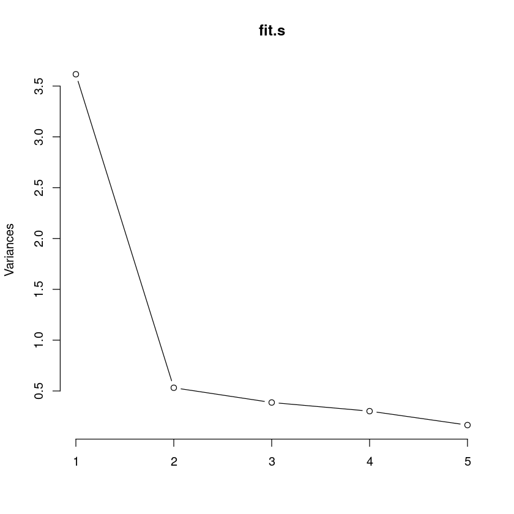

```r
#Spree plot
## A scree plot serves as a diagnostic tool to assess the effectiveness of PCA on your data.
# Principal components are generated in order of the amount of variation:
#PC1 captures the highest variance, PC2 follows, and so forth.
#Each component contributes valuable information about the data, and in a PCA,
#the number of principal components matches the number of characteristics.
#Omitting any principal components results in loss of information.

plot.pca = plot(fit.s, type="l")

#The varaiance captured by PC2, PC3, are much smaller than that of PC1
```

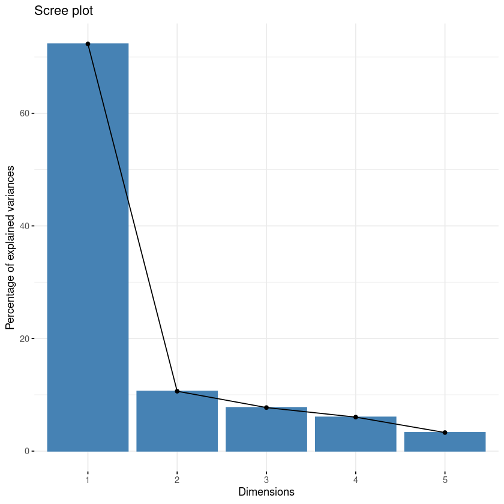

```r
#Additional spree plot to visulize the results of PCA
library(factoextra)
fviz_eig(fit.s)
```

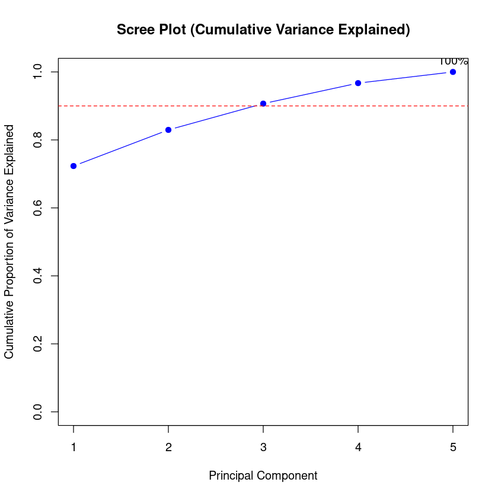

```r
#The proprtion of variance captured by the first PC
num.of.variables = 5
p.var = (fit.s$sdev[1:num.of.variables])^2/sum((fit.s$sdev)^2)
#About 72.3% of variance of all variables can be captured by the first pricipal component

#To find the cumulative variation explained
cum.pvar = cumsum(p.var)
#cum.pvar

#plot.pca = plot(fit.s, type="l")

# Scree plot for cumulative variance explained
plot(1:num.of.variables, cum.pvar, type = 'b', pch = 19, col = 'blue',
     ylim = c(0, 1), xlab = 'Principal Component',
     ylab = 'Cumulative Proportion of Variance Explained',
     main = 'Scree Plot (Cumulative Variance Explained)')
abline(h = 0.9, col = 'red', lty = 2)  # Add a line at 90% threshold
text(x = num.of.variables, y = cum.pvar[num.of.variables],
     labels = paste0(round(cum.pvar[num.of.variables]*100,1), "%"), pos = 3)


# Determine number of PCs needed for at least 90% variance
num.PCs.90 <- sum(cum.pvar < 0.9) + 1

#3
```

[figure not shown]

```r
# Prepare data frame for ggplot
df <- data.frame(
  PC = 1:num.of.variables,
  CumulativeVariance = cum.pvar
)

# Plot using ggplot2
ggplot(df, aes(x = PC, y = CumulativeVariance)) +
  geom_line(color = "blue") +
  geom_point(color = "blue", size = 3) +
  geom_hline(yintercept = 0.90, linetype = "dashed", color = "red") +
  geom_text(aes(label = paste0(round(CumulativeVariance, 1), "%")),
            vjust = -0.5) +
  scale_x_continuous(breaks = 1:num.of.variables) +
  scale_y_continuous(limits = c(0, 1), breaks = seq(0, 100, 10)) +
  labs(
    title = "Scree Plot: Cumulative Variance Explained",
    x = "Principal Component",
    y = "Cumulative Variance Explained (%)"
  ) +
  theme_minimal(base_size = 14)
```

# Biplot of PCA

A **biplot** is a graphical representation that simultaneously displays **observations (objects)** and **variables** in the space defined by the principal components. Key aspects of interpreting a biplot include the **angles between vectors**, the **lengths of vectors**, and the **relative positions of objects and variables**.

## 1. Angles Between Variable Vectors

The angle between two variable vectors reflects the correlation between the corresponding variables:

- **90°**: No correlation between the variables.
- **Less than 90°**: Positive correlation. The smaller the angle, the stronger the positive correlation.
- **Greater than 90°**: Negative correlation. The closer the angle is to 180°, the stronger the negative correlation.

## 2. Length of Variable Vectors

The length of a variable vector represents the variance of that variable:

- **Longer vectors**: Higher variance and a stronger contribution to the principal components.
- **Shorter vectors**: Lower variance and a smaller influence on the PCA space.

## 3. Position of Objects Relative to Variables

The position of an object (observation) relative to a variable vector provides information about its value for that variable:

- **Closer projection onto a vector**: Higher value of that variable for the object.
- **Farther projection from a vector**: Lower value of the variable for that object.

## 4. Distance Between Objects

The distance between two objects reflects their similarity across the variables represented in the plot:

- **Closer distance**: Objects have similar variable profiles.
- **Greater distance**: Objects are more dissimilar in terms of the variables.

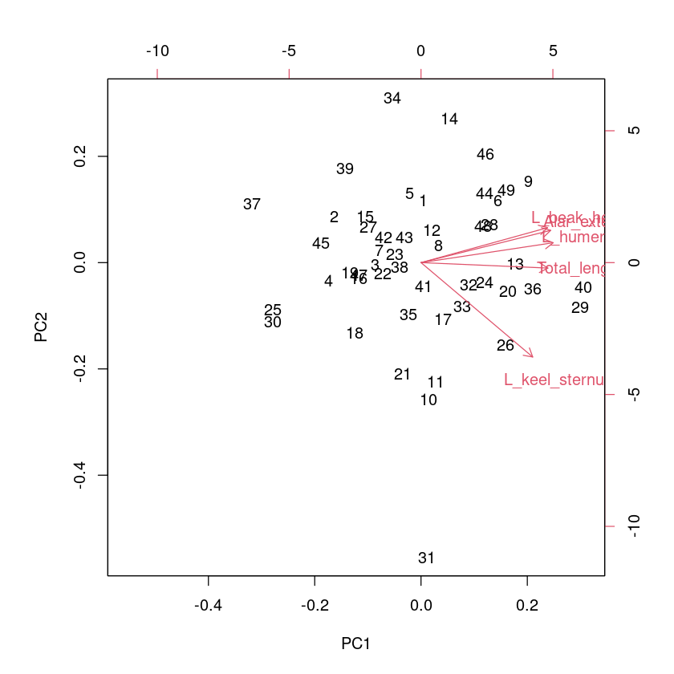

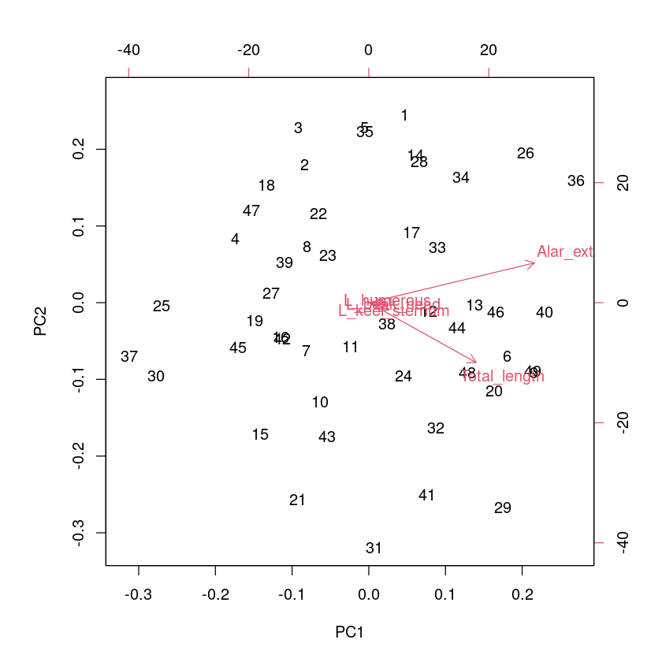

```r
#biplot()

biplot(fit.s)

biplot(fit)
#Show the relationship between the variables in terms of PC1 and PC2.
```

# Source: https://cran.r-project.org/web/packages/Sleuth2/refman/Sleuth2.html#ex2016

Description Hermon Bumpus analysed various characteristics of some house sparrows that were found on the ground after a severe winter storm in 1898. Some of the sparrows survived and some perished. This data set contains the survival status, age, the length from tip of beak to tip of tail (in mm), the alar extent (length from tip to tip of the extended wings, in mm), the weight in grams, the length of the head in mm, the length of the humerus (arm bone, in inches), the length of the femur (thigh bones, in inches), the length of the tibio–tarsus (leg bone, in inches), the breadth of the skull in inches and the length of the sternum in inches.

Excerise: Run a principle component analysis for the data of ex2016 in R package "Sleuth2" .

```r
#https://cran.r-project.org/web/packages/Sleuth2/refman/Sleuth2.html#ex2016
#library(Sleuth2)
#data(ex2016, package = "Sleuth2")
#dat = ex2016

url <- "https://cran.r-project.org/src/contrib/Sleuth2_2.0-7.tar.gz"
download.file(url, destfile="Sleuth2_2.0-7.tar.gz")
untar("Sleuth2_2.0-7.tar.gz", files = "Sleuth2/data/ex2016.rda", exdir="Sleuth2_unpacked")
load("Sleuth2_unpacked/Sleuth2/data/ex2016.rda")
head(ex2016)

dat = ex2016
```

A data.frame: 6 × 11

|  | Status <fct> | AG <fct> | TL <dbl> | AE <dbl> | WT <dbl> | BH <dbl> | HL <dbl> | FL <dbl> | TT <dbl> | SK <dbl> | KL <dbl> |
| --- | --- | --- | --- | --- | --- | --- | --- | --- | --- | --- | --- |
| 1 | Survived | adult | 154 | 241 | 24.5 | 31.2 | 0.687 | 0.668 | 1.022 | 0.587 | 0.830 |
| 2 | Survived | adult | 160 | 252 | 26.9 | 30.8 | 0.736 | 0.709 | 1.180 | 0.602 | 0.841 |
| 3 | Survived | adult | 155 | 243 | 26.9 | 30.6 | 0.733 | 0.704 | 1.151 | 0.602 | 0.846 |
| 4 | Survived | adult | 154 | 245 | 24.3 | 31.7 | 0.741 | 0.688 | 1.146 | 0.584 | 0.839 |
| 5 | Survived | adult | 156 | 247 | 24.1 | 31.5 | 0.715 | 0.706 | 1.129 | 0.575 | 0.821 |
| 6 | Survived | adult | 161 | 253 | 26.5 | 31.8 | 0.780 | 0.743 | 1.144 | 0.607 | 0.893 |

Run PCA on the **scaled data**.

**Questions:**

1. What are the first and second principal components (PCs)?
2. How much variation is explained by the first three PCs?
3. Using **Kaiser’s criterion**, how many PCs should be retained?
4. Create a **scree plot**. Based on it, how many PCs are needed?
5. To capture at least **$85\%$** of the total variation, how many PCs should be retained?